# M11-2: Introduction to Functional Programming in R

Author

Asif Kachroo

Published

April 26, 2026

## 1 Question 1: Create a vector “quantity” and assign 50 to it. If the quantity is greater than 20, your code should print “You sold a lot”; otherwise, print “Not enough for today.”

```r
quantity <- c(50)

if (quantity > 20) {
  print("You sold a lot")
} else {
  print("Not enough for today.")
}
```

```
[1] "You sold a lot"
```

## 2 Question 2: Create a vector “sales” and assign the value 25 to it. If the value is less than 20, your code should print “Not enough for today.” If the quantity sold is between 20 and 30 inclusively, print “Average Day.” If your sales amount is greater than 30, print out “You had a great day!”

```r
sales <- c(25)

if(sales < 20){
  print("Not enough for today")
} else if (sales>=20 & sales <= 30){
    print("Average Day")
} else{
      print("You had a great day!")
    }
```

```
[1] "Average Day"
```

```r
category <- "B"
price <- 100

if (category == "A") {
  tax <- price * 0.08
  price <- price + tax
  print(paste("A tax rate of 8% is applied. The total price is", price))
} else if (category == "B") {
  tax <- price * 0.1
  price <- price + tax
  print(paste("A tax rate of 10% is applied. The total price is", price))
} else {
  tax <- price * 0.2
  price <- price + tax
  print(paste("A tax rate of 20% is applied. The total price is", price))
}
```

```
[1] "A tax rate of 10% is applied. The total price is 110"
```

## 4 Question 4: Create a for loop to count the even numbers in a vector q4. This vector must contain the values 2, 5, 3, 9, 8, 11, and 6. Your output must be 3.

```r
q4 <- c(2, 5, 3, 9, 8, 11, 6)

count <- 0

for(i in q4){
  if(i %% 2 == 0){
    count <- count + 1
  }
}

count
```

```
[1] 3
```

## 5 Question 5: Create a vector q5 in the range of 1 to 8. For each one of the numbers in the vector, if it is greater than 4 and even, print it. Otherwise, print “Condition not satisfied”. Your output must have 8 lines, showing the numbers 6 and 8 in two of the eight lines.

```r
q5 <- 1:8

for(i in q5){
  if(i > 4 & i %% 2 == 0){
    print(i)
  } else {
    print("Condition not satisfied")
  }
}
```

```
[1] "Condition not satisfied"
[1] "Condition not satisfied"
[1] "Condition not satisfied"
[1] "Condition not satisfied"
[1] "Condition not satisfied"
[1] 6
[1] "Condition not satisfied"
[1] 8
```

## 6 Question 6: Create a function called “pow” that takes two arguments: x and y. The first argument is raised to the power of the second one, and prints the result like this: “8 raised to the power of 2 is 64.” Lastly, call the function with those values after creating the function.

```r
pow <- function(x, y){
  result <- x^y
  print(paste(x, "raised to the power of", y, "is", result))
}

pow(8, 2)
```

```
[1] "8 raised to the power of 2 is 64"
```

## 7 Question 7

```r
#Q7.1. Run this line of code: df <- data.frame(x = 1:4, y = 5:8, z = 10:13). Use the apply function to get the mean and sum of each ROW on this dataframe. Add them to the data frame.

df <- data.frame(x = 1:4, y = 5:8, z = 10:13)

df$mean <- apply(df, 1, mean)
df$sum <- apply(df, 1, sum)

df
```

```
  x y  z     mean      sum
1 1 5 10 5.333333 21.33333
2 2 6 11 6.333333 25.33333
3 3 7 12 7.333333 29.33333
4 4 8 13 8.333333 33.33333
```

```r
#Q7.2. Create a vector called q8 and assign the values 12, 18, and 6. Next, use the apply family and map family functions to calculate the square root of each element.

library(purrr)

q8 <- c(12, 18, 6)

lapply(q8, sqrt)
```

```
[[1]]
[1] 3.464102

[[2]]
[1] 4.242641

[[3]]
[1] 2.44949
```

```r
map(q8, sqrt)
```

```
[[1]]
[1] 3.464102

[[2]]
[1] 4.242641

[[3]]
[1] 2.44949
```

```r
#Q7.3. Run this code below: q9 <- list(A = 1:5, B = 6:20, C = 1). Use the apply family and map family functions to calculate the number of components of each element of this list. *Hint*: Use the length function.

q9 <- list(A = 1:5, B = 6:20, C = 1)

lapply(q9, length)
```

```
$A
[1] 5

$B
[1] 15

$C
[1] 1
```

```r
map(q9, length)
```

```
$A
[1] 5

$B
[1] 15

$C
[1] 1
```

### 7.1 Q7.4. What is the difference between lapply and sapply functions. Which map functions are similar to them? Consider that you want to calculate the exponentials of three numbers. In this case, which function you should use and why? Type your answer as a comment?

lapply returns a list sapply attempts to simplify the result into a vector or matrix

map() is similar to lapply() map_dbl(), map_int() are similar to sapply()

For exponentials, use sapply or map_dbl because they return numeric vectors

## 8 Question 8

```r
#Q8.1: First, execute the following codes in the code chunk to read the data into R and set the global theme.

library(tidyverse)

theme_set(theme_bw())

student_ratio <- read_csv("https://raw.githubusercontent.com/rfordatascience/tidytuesday/master/data/2019/2019-05-07/student_teacher_ratio.csv")

#Q8.2. Explore the data. Especially count the number of "year", the "indicator", and "country", separately.

student_ratio %>% count(year)
```

```
# A tibble: 7 × 2
   year     n
  <dbl> <int>
1  2012   887
2  2013   880
3  2014   913
4  2015   921
5  2016   917
6  2017   635
7  2018    36
```

```r
student_ratio %>% count(indicator)
```

```
# A tibble: 7 × 2
  indicator                                 n
  <chr>                                 <int>
1 Lower Secondary Education               739
2 Post-Secondary Non-Tertiary Education   494
3 Pre-Primary Education                   837
4 Primary Education                      1029
5 Secondary Education                     840
6 Tertiary Education                      550
7 Upper Secondary Education               700
```

```r
student_ratio %>% count(country)
```

```
# A tibble: 232 × 2
   country                  n
   <chr>                <int>
 1 Afghanistan             13
 2 Africa (Northern)       30
 3 Africa (Sub-Saharan)    28
 4 Albania                 36
 5 Algeria                 18
 6 Andorra                 29
 7 Angola                   7
 8 Antigua and Barbuda     13
 9 Arab States             30
10 Argentina                5
# ℹ 222 more rows
```

```r
#Q8.3. Next, draw a chart that shows the top and bottom 10 countries in student-teacher ratio for 2012.

data_2012 <- student_ratio %>% filter(year == 2012)

top10 <- data_2012 %>% top_n(10, student_teacher_ratio)
```

```
Error in `filter()`:
ℹ In argument: `top_n_rank(10, student_teacher_ratio)`.
Caused by error:
! object 'student_teacher_ratio' not found
```

```r
bottom10 <- data_2012 %>% top_n(-10, student_teacher_ratio)
```

```
Error in `filter()`:
ℹ In argument: `top_n_rank(-10, student_teacher_ratio)`.
Caused by error:
! object 'student_teacher_ratio' not found
```

```r
bind_rows(top10, bottom10) %>%
  ggplot(aes(x = reorder(country, student_teacher_ratio), y = student_teacher_ratio)) +
  geom_col() +
  coord_flip()
```

[output not shown]

```
Error:
! object 'top10' not found
```

```r
#Q8.4. Note that there are six years from 2012 to 2017 that have a significant number of observations, conducive for drawing charts by year. Since you don't want to copy and paste the code again and again, you want to create a function that allows you to use it to draw all the charts by simply entering "year" information into the function. You will want to show "year" information in the chart as a subtitle. Create such a function.

plot_ratio <- function(year_input){
  student_ratio %>%
    filter(year == year_input) %>%
    top_n(10, student_teacher_ratio) %>%
    ggplot(aes(x = reorder(country, student_teacher_ratio), y = student_teacher_ratio)) +
    geom_col() +
    coord_flip() +
    labs(subtitle = paste("Year:", year_input))
}

#Q8.5. Draw all charts for 2012 through 2017 using the function.

years <- 2012:2017

lapply(years, plot_ratio)
```

[output not shown]

```
Error in `filter()`:
ℹ In argument: `top_n_rank(10, student_teacher_ratio)`.
Caused by error:
! object 'student_teacher_ratio' not found
```

## 9 Question 9

```r
#Q9.0. Read the following data in R and be prepared for analysis.

animal_outcomes <- readr::read_csv('https://raw.githubusercontent.com/rfordatascience/tidytuesday/master/data/2020/2020-07-21/animal_outcomes.csv')
animal_complaints <- readr::read_csv('https://raw.githubusercontent.com/rfordatascience/tidytuesday/master/data/2020/2020-07-21/animal_complaints.csv')
brisbane_complaints <- readr::read_csv('https://raw.githubusercontent.com/rfordatascience/tidytuesday/master/data/2020/2020-07-21/brisbane_complaints.csv')

#Q9.1. First, briefly take a look at each data set. You will notice that some variables are lower case while others are upper case. You will also notice that some variables are consist of more than one word.

glimpse(animal_outcomes)
```

```
Rows: 664
Columns: 12
$ year        <dbl> 1999, 1999, 1999, 1999, 1999, 1999, 1999, 1999, 1999, 1999…
$ animal_type <chr> "Dogs", "Dogs", "Dogs", "Dogs", "Cats", "Cats", "Cats", "C…
$ outcome     <chr> "Reclaimed", "Rehomed", "Other", "Euthanized", "Reclaimed"…
$ ACT         <dbl> 610, 1245, 12, 360, 111, 1442, 0, 1007, 0, 1, 0, 0, 2, 90,…
$ NSW         <dbl> 3140, 7525, 745, 9221, 201, 3913, 447, 8205, 0, 12, 0, 8, …
$ NT          <dbl> 205, 526, 955, 9, 22, 269, 0, 847, 1, 3, 0, 0, 0, 120, 0, …
$ QLD         <dbl> 1392, 5489, 860, 9214, 206, 3901, 386, 10554, 0, 3, 11, 1,…
$ SA          <dbl> 2329, 1105, 380, 1701, 157, 1055, 46, 3415, 2, 10, 1, 0, 1…
$ TAS         <dbl> 516, 480, 168, 599, 31, 752, 124, 1056, 1, 0, 2, 0, 1, 25,…
$ VIC         <dbl> 7130, 4908, 1001, 5217, 884, 3768, 1501, 6113, 87, 19, 0, …
$ WA          <dbl> 1, 137, 6, 18, 0, 62, 5, 5, 0, 0, 0, 0, 0, 3, 0, 0, 0, 0, …
$ Total       <dbl> 15323, 21415, 4127, 26339, 1612, 15162, 2509, 31202, 91, 4…
```

```r
glimpse(animal_complaints)
```

```
Rows: 42,413
Columns: 5
$ `Animal Type`        <chr> "dog", "dog", "dog", "dog", "dog", "dog", "dog", …
$ `Complaint Type`     <chr> "Aggressive Animal", "Noise", "Noise", "Private I…
$ `Date Received`      <chr> "June 2020", "June 2020", "June 2020", "June 2020…
$ Suburb               <chr> "Alice River", "Alice River", "Alice River", "Ali…
$ `Electoral Division` <chr> "Division 1", "Division 1", "Division 1", "Divisi…
```

```r
glimpse(brisbane_complaints)
```

```
Rows: 31,330
Columns: 7
$ nature             <chr> "Animal", "Animal", "Animal", "Animal", "Animal", "…
$ animal_type        <chr> "Dog", "Dog", "Dog", "Dog", "Attack", "Attack", "Do…
$ category           <chr> "Fencing Issues", "Fencing Issues", "Defecating In …
$ suburb             <chr> "SUNNYBANK", "SUNNYBANK HILLS", "SUNNYBANK", "SUNNY…
$ date_range         <chr> "1st-quarter-2016-17.csv", "1st-quarter-2016-17.csv…
$ responsible_office <chr> NA, NA, NA, NA, NA, NA, NA, NA, NA, NA, NA, NA, NA,…
$ city               <chr> "Brisbane", "Brisbane", "Brisbane", "Brisbane", "Br…
```

```r
#Q9.2. Create a pipeable function that will help you clean up the variable names across the data set, clean them up using the function, and reassign the data sets to the same names to overwrite them.

library(janitor)

clean_names_fn <- function(df){
  df %>% clean_names()
}

animal_outcomes <- clean_names_fn(animal_outcomes)
animal_complaints <- clean_names_fn(animal_complaints)
brisbane_complaints <- clean_names_fn(brisbane_complaints)

#Q9.3. Create a pipeable function that can draw a bar chart showing a count of a variable from any of the three data sets above.

plot_bar <- function(df, var){
  df %>%
    count({{var}}) %>%
    ggplot(aes(x = reorder({{var}}, n), y = n)) +
    geom_col() +
    coord_flip()
}

#Q9.4. Then, using the function, create two bar charts of your interest from each data set.

plot_bar(animal_outcomes, outcome_type)
```

```
Error in `count()`:
! Must group by variables found in `.data`.
✖ Column `outcome_type` is not found.
```

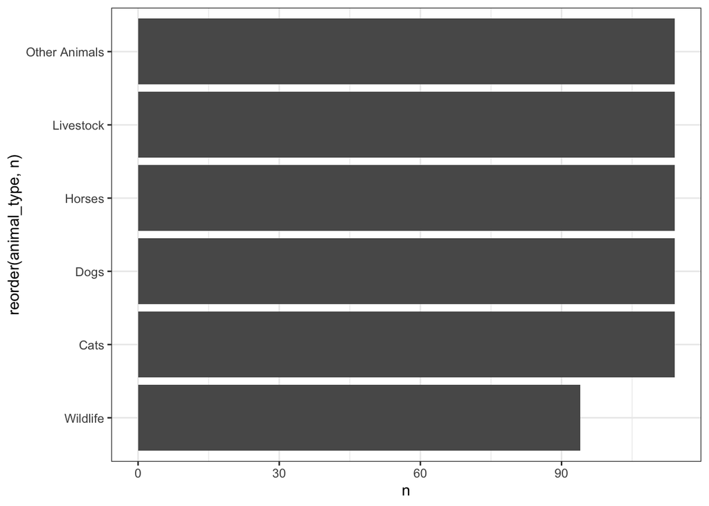

```r
plot_bar(animal_outcomes, animal_type)
```

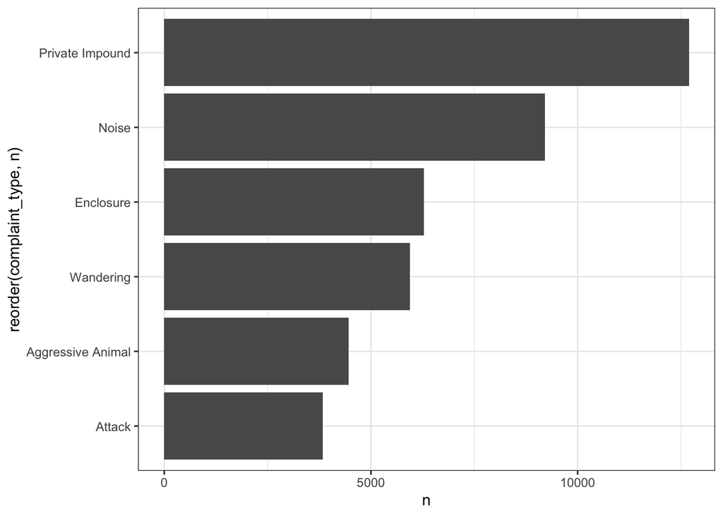

```r
plot_bar(animal_complaints, complaint_type)
```

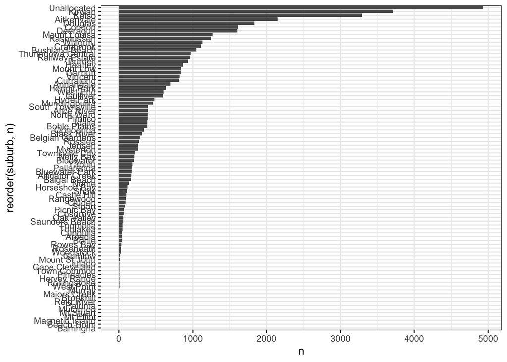

```r
plot_bar(animal_complaints, suburb)
```

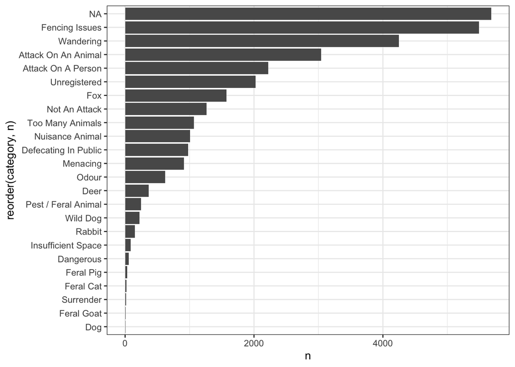

```r
plot_bar(brisbane_complaints, category)
```

[figure not shown]

```r
plot_bar(brisbane_complaints, suburb)
```

## 10 Question 10: In this question, you will work with “airquality” data set, which is built-in data available from R Studio. The goal is to create a function that calculates average Ozone amount for each month. *Hints*: Use nested data. You will have to create multiple functions with one function embedded in another. Also, use one of the map() functions.

```r
library(tidyverse)

calc_mean <- function(data){
  mean(data$Ozone, na.rm = TRUE)
}

ozone_by_month <- function(df){
  df %>%
    group_by(Month) %>%
    nest() %>%
    mutate(mean_ozone = map_dbl(data, calc_mean)) %>%
    select(Month, mean_ozone)
}

ozone_by_month(airquality)
```

```
# A tibble: 5 × 2
# Groups:   Month [5]
  Month mean_ozone
  <int>      <dbl>
1     5       23.6
2     6       29.4
3     7       59.1
4     8       60.0
5     9       31.4
```